# 3_apartments

## Предобработка данных

### Поиск пропущенных значений в столбцах

```python
# Функция поиска соотношения пропущенных значений в столбце
data = pd.read_csv('https://code.s3.yandex.net/datasets/real_estate_data.csv', sep='\t')
pd.DataFrame(data.isna().mean()).style.background_gradient('Reds').format({0:'{:.1%}'})
```

|  | 0 |
| --- | --- |
| total_images | 0.0% |
| last_price | 0.0% |
| total_area | 0.0% |
| first_day_exposition | 0.0% |
| rooms | 0.0% |
| ceiling_height | 38.8% |
| floors_total | 0.4% |
| living_area | 8.0% |
| floor | 0.0% |
| is_apartment | 88.3% |
| studio | 0.0% |
| open_plan | 0.0% |
| kitchen_area | 9.6% |
| balcony | 48.6% |
| locality_name | 0.2% |
| airports_nearest | 23.4% |
| cityCenters_nearest | 23.3% |
| parks_around3000 | 23.3% |
| parks_nearest | 65.9% |
| ponds_around3000 | 23.3% |
| ponds_nearest | 61.6% |
| days_exposition | 13.4% |

`ceiling_height` - Пропущенных значений 38,8%. Будем заполнять медианной относительно населенного пункта. Остальные заменим общей медианной.

`floors_total` - Пропущенных значений 0,4%. Слишком маленький процент пропусков, строки можно удалить.

`living_area` - Пропущенных значений 8%. Заполним соотношением Общей площадью на среднее значение.

`is_apartment` - Пропущенных значений 88,3%. Заполним пропуски `False`.

`kitchen_area` - Пропущенных значений 9,6%. Заполним соотношением Общей площадью на среднее значение.

`balcony` - Пропущенных значений 48,6%. Скорее всего при не заполненном количестве балконов, их нету. Заполним пропуски значением - 0.

`locality_name` - Пропущенных значений 0,2%. Так как этот параметр очень важный, оставлять пропуски нельзя. Процент пропущенных значений маленький. Строки можно удалить.

`airports_nearest` - Пропущенных значений 23%.Будем заполнять медианной относительно населенного пункта. Остальные оставим как есть.

`cityCenters_nearest` - Пропущенных значений 23,3%. Будем заполнять медианной относительно населенного пункта. Остальные оставим как есть.

`parks_around3000` - Пропущенных значений 23,3%. Оставим как есть.

`parks_nearest` - Пропущенных значений 65.9%. Будем заполнять медианной относительно населенного пункта. Остальные оставим как есть.

`ponds_around3000` - Пропущенных значений 23,3%. Оставим как есть.

`ponds_nearest` - Пропущенных значений 61,6%. Будем заполнять медианной относительно населенного пункта. Остальные оставим как есть.

`days_exposition` - Пропущенных значений 13,4%. Оставим как есть.

### Удаление строк с пропущенными значениями.

```python
data = data.dropna(subset = ['floors_total', 'locality_name']).reset_index(drop=True)
#data.info()
```

### Заполнение пропущенных значений

```python
# Замена пропущенных значений is_apartment на False.
data['is_apartment'] = data['is_apartment'].fillna(False)

# Замена пропущенных значений balcony 0.
data['balcony'] = data['balcony'].fillna(0)

# Замена пропущенных значений ceiling_height на медиану по населенному пункту
for locality_name in data['locality_name'].unique():
  median = data.loc[data['locality_name'] == locality_name, 'ceiling_height'].median()
  data.loc[(data['ceiling_height'].isna()) & (data['locality_name'] == locality_name), 'ceiling_height'] = median
# Замена пропущенных значений ceiling_height на медиану, для которых не нашлось населенного пункта
data.loc[data['ceiling_height'].isna(), 'ceiling_height'] = data['ceiling_height'].median()

# Отношение средней Общей площади там, где пропущенны значения в жилой площади на среднюю жилую площадь там, где не пропущенные значения в жилой площади.
ratio_total_living = data['total_area'][data['living_area'].isnull() == True].mean() / data['living_area'][data['living_area'].isnull() == False].mean()
# Заполняем пропуски в жилой площади с помощью деления общей площади на ratio_total_living
data['living_area'] = data['living_area'].fillna(data['total_area'] / ratio_total_living)

# Отношение средней Общей площади там, где пропущенны значения в площади кухни на среднюю площадь кухни там, где не пропущенные значения в площади кухни.
ratio_total_kitchen = data['total_area'][data['kitchen_area'].isnull() == True].mean() / data['kitchen_area'][data['kitchen_area'].isnull() == False].mean()
# Заполняем пропуски в площади кухни с помощью деления общей площади на ratio_total_kitchen
data['kitchen_area'] = data['kitchen_area'].fillna(data['total_area'] / ratio_total_kitchen)

# Замена пропущенных значений cityCenters_nearest на медиану по населенному пункту
for locality_name in data['locality_name'].unique():
  median = data.loc[data['locality_name'] == locality_name, 'cityCenters_nearest'].median()
  data.loc[(data['cityCenters_nearest'].isna()) & (data['locality_name'] == locality_name), 'cityCenters_nearest'] = median

# Замена пропущенных значений airports_nearest на медиану по населенному пункту
for locality_name in data['locality_name'].unique():
  median = data.loc[data['locality_name'] == locality_name, 'airports_nearest'].median()
  data.loc[(data['airports_nearest'].isna()) & (data['locality_name'] == locality_name), 'airports_nearest'] = median

# Замена пропущенных значений parks_nearest на медиану по населенному пункту
for locality_name in data['locality_name'].unique():
  median = data.loc[data['locality_name'] == locality_name, 'parks_nearest'].median()
  data.loc[(data['parks_nearest'].isna()) & (data['locality_name'] == locality_name), 'parks_nearest'] = median


# Замена пропущенных значений ponds_nearest на медиану по населенному пункту
for locality_name in data['locality_name'].unique():
  median = data.loc[data['locality_name'] == locality_name, 'ponds_nearest'].median()
  data.loc[(data['ponds_nearest'].isna()) & (data['locality_name'] == locality_name), 'ponds_nearest'] = median
```

### Изменение типов данных

В целочисленный тип:

`floors_total`, `balcony` - значение всегда целое число.

`last_price` - Слишком большие суммы, что бы указывать копейки

В datetime:

`first_day_exposition` - в удобный формат для чтения.

В булевый тип

`is_apartment` - значение указаны как `True` / `False`

```python
# Изменение типа данных столбца first_day_exposition на datetime
data['first_day_exposition'] = pd.to_datetime(data['first_day_exposition'], format='%Y-%m-%dT%H:%M:%S')

# Изменение типа данных столбца is_apartment на bool
data['is_apartment'] = data['is_apartment'].astype('bool')

# Изменение типа данных столбца floors_total, balcony на int
data['floors_total'] = data['floors_total'].astype(int)
data['balcony'] = data['balcony'].astype(int)
data['last_price'] = data['last_price'].astype(int)
```

### Устранение неявных дубликатов в названиях населённых пунктов

```python
# Замена всех населенных пунктов по типу Поселок к одному названию
data['locality_name'] = data['locality_name'].str.replace('посёлок', 'поселок')
data['locality_name'] = data['locality_name'].str.replace('посёлок городского типа', 'поселок')
data['locality_name'] = data['locality_name'].str.replace('поселок городского типа', 'поселок')
data['locality_name'] = data['locality_name'].str.replace('городской поселок', 'поселок')
data['locality_name'] = data['locality_name'].str.replace('коттеджный поселок', 'поселок')
#data['locality_name'].unique()
```

### Устранение редких и выбивающиеся значения (аномалии) во всех столбцах

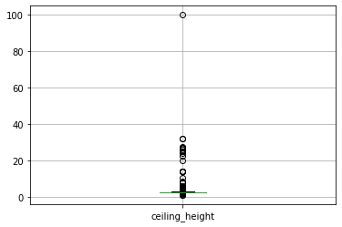

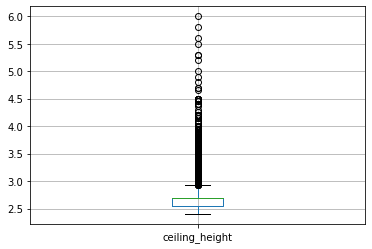

```python
# Устранение редких и аномальных значений в столбце ceiling_height
data.boxplot(column='ceiling_height')
plt.show()
# Значение 24 и выше ошибка при заполнении, в среднем, этот параметр колеблется от 2,4
data.loc[data['ceiling_height'] >= 24, 'ceiling_height'] = data['ceiling_height'] / 10
# Высота потолков должна быть больше 2.4 и меньше 8
data = data[(data['ceiling_height'] >= 2.4) & (data['ceiling_height'] < 8)]
data.boxplot(column='ceiling_height')
plt.show()
```

Удалили потолки меньше 2.4 и больше 8

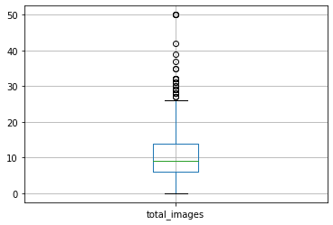

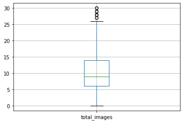

```python
# Устранение редких и аномальных значений в столбце total_images
data.boxplot(column='total_images')
plt.show()
# На сайте стоит ограничение в 30 фото
data = data[data['total_images'] <= 30]
data.boxplot(column='total_images')
plt.show()
```

Удалили объявления с фото больше 30

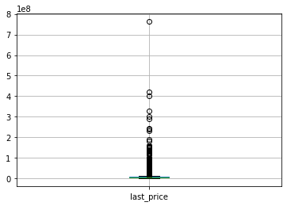

```python
# Устранение редких и аномальных значений в столбце last_price
data['last_price'].unique()
data.boxplot(column='last_price')
plt.show()
```

Редких и аномальных значений нету, цена может быть любой

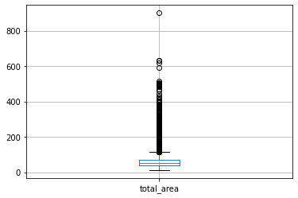

```
count    23518.000000
mean        60.318774
std         35.669809
min         12.000000
25%         40.000000
50%         52.000000
75%         69.700000
max        900.000000
Name: total_area, dtype: float64
```

```python
# Устранение редких и аномальных значений в столбце total_area
# Округление до 2 знаков после зяпятой
data['total_area'] = data['total_area'].round(2)
data.boxplot(column='total_area')
plt.show()
data['total_area'].describe()
```

Редких и аномальных значений нету, все значения больше 8

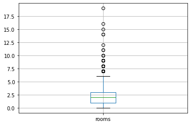

```
count    23518.000000
mean         2.070287
std          1.078790
min          0.000000
25%          1.000000
50%          2.000000
75%          3.000000
max         19.000000
Name: rooms, dtype: float64
```

```python
# Устранение редких и аномальных значений в столбце rooms
data.boxplot(column='rooms')
plt.show()
data['rooms'].describe()
```

Редких и аномальных значений нету, квартиры бывают разные

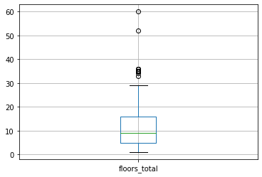

```
count    23518.000000
mean        10.676673
std          6.592461
min          1.000000
25%          5.000000
50%          9.000000
75%         16.000000
max         60.000000
Name: floors_total, dtype: float64
```

```python
# Устранение редких и аномальных значений в столбце floors_total
data.boxplot(column='floors_total')
plt.show()
data['floors_total'].describe()
```

Редких и аномальных значений нету. Максимально большое здание Санкт-Петербурга имеет 87 этажей.

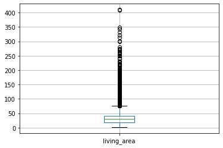

```
count    23518.000000
mean        34.448731
std         22.260081
min          2.000000
25%         19.000000
50%         30.000000
75%         42.000000
max        409.700000
Name: living_area, dtype: float64
```

```python
# Устранение редких и аномальных значений в столбце living_area
# Округление до 2 знаков после зяпятой
data['living_area'] = data['living_area'].round(2)
data.boxplot(column='living_area')
plt.show()
data['living_area'].describe()
```

Редких и аномальных значений нету, квартиры бывают разные

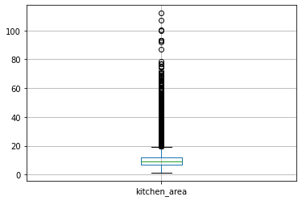

```
count    23518.000000
mean        10.561877
std          6.090424
min          1.300000
25%          7.000000
50%          9.000000
75%         12.000000
max        112.000000
Name: kitchen_area, dtype: float64
```

```python
# Устранение редких и аномальных значений в столбце kitchen_area
# Округление до 2 знаков после зяпятой
data['kitchen_area'] = data['kitchen_area'].round(2)
data.boxplot(column='kitchen_area')
plt.show()
data['kitchen_area'].describe()
```

Редких и аномальных значений нету, квартиры бывают разные

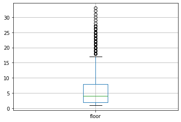

```
count    23518.000000
mean         5.877966
std          4.871159
min          1.000000
25%          2.000000
50%          4.000000
75%          8.000000
max         33.000000
Name: floor, dtype: float64
```

```python
# Устранение редких и аномальных значений в столбце floor
data.boxplot(column='floor')
plt.show()
data['floor'].describe()
```

Редких и аномальных значений нету

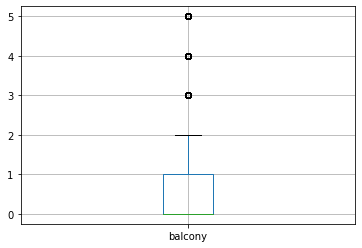

```
count    23518.000000
mean         0.592993
std          0.959532
min          0.000000
25%          0.000000
50%          0.000000
75%          1.000000
max          5.000000
Name: balcony, dtype: float64
```

```python
# Устранение редких и аномальных значений в столбце balcony
data.boxplot(column='balcony')
plt.show()
data['balcony'].describe()
```

Редких и аномальных значений нету

```python
# Устранение редких и аномальных значений в столбце airports_nearest
data.boxplot(column='airports_nearest')
plt.show()
data['airports_nearest'].describe()
```

[output not shown]

```
count    18107.000000
mean     28790.224803
std      12609.367638
min          0.000000
25%      18590.000000
50%      26763.000000
75%      37227.000000
max      84869.000000
Name: airports_nearest, dtype: float64
```

Редких и аномальных значений нету

```python
# Устранение редких и аномальных значений в столбце airports_nearest
data.boxplot(column='airports_nearest')
plt.show()
data['airports_nearest'].describe()
```

[output not shown]

```
count    18107.000000
mean     28790.224803
std      12609.367638
min          0.000000
25%      18590.000000
50%      26763.000000
75%      37227.000000
max      84869.000000
Name: airports_nearest, dtype: float64
```

Редких и аномальных значений нету

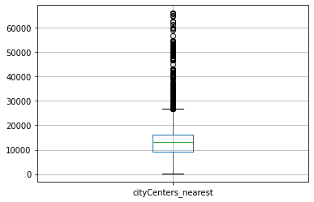

```
count    18107.000000
mean     14197.634865
std       8611.768442
min        181.000000
25%       9265.000000
50%      13073.000000
75%      16280.000000
max      65968.000000
Name: cityCenters_nearest, dtype: float64
```

```python
# Устранение редких и аномальных значений в столбце cityCenters_nearest
data.boxplot(column='cityCenters_nearest')
plt.show()
data['cityCenters_nearest'].describe()
```

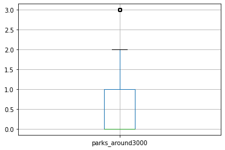

```
count    18039.000000
mean         0.611564
std          0.802177
min          0.000000
25%          0.000000
50%          0.000000
75%          1.000000
max          3.000000
Name: parks_around3000, dtype: float64
```

```python
# Устранение редких и аномальных значений в столбце parks_around3000
data.boxplot(column='parks_around3000')
plt.show()
data['parks_around3000'].describe()
```

Редких и аномальных значений нету

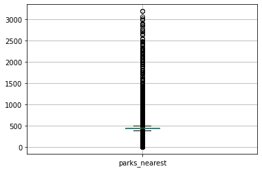

```
count    17554.000000
mean       475.913097
std        235.077910
min          1.000000
25%        433.000000
50%        460.000000
75%        460.000000
max       3190.000000
Name: parks_nearest, dtype: float64
```

```python
# Устранение редких и аномальных значений в столбце parks_nearest
data.boxplot(column='parks_nearest')
plt.show()
data['parks_nearest'].describe()
```

Редких и аномальных значений нету

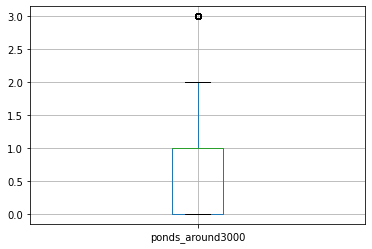

```
count    18039.000000
mean         0.769389
std          0.938533
min          0.000000
25%          0.000000
50%          1.000000
75%          1.000000
max          3.000000
Name: ponds_around3000, dtype: float64
```

```python
# Устранение редких и аномальных значений в столбце ponds_around3000
data.boxplot(column='ponds_around3000')
plt.show()
data['ponds_around3000'].describe()
```

Редких и аномальных значений нету

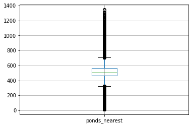

```
count    18023.000000
mean       510.711397
std        199.841278
min         13.000000
25%        466.000000
50%        504.000000
75%        563.000000
max       1344.000000
Name: ponds_nearest, dtype: float64
```

```python
# Устранение редких и аномальных значений в столбце ponds_nearest
data.boxplot(column='ponds_nearest')
plt.show()
data['ponds_nearest'].describe()
```

Редких и аномальных значений нету

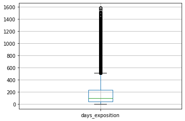

```
count    20351.000000
mean       180.857648
std        219.881747
min          1.000000
25%         45.000000
50%         95.000000
75%        231.000000
max       1580.000000
Name: days_exposition, dtype: float64
```

```python
# Устранение редких и аномальных значений в столбце days_exposition
data.boxplot(column='days_exposition')
plt.show()
data['days_exposition'].describe()
```

Редких и аномальных значений нету

Устранение редких и аномальных значений в столбцах is_apartment, studio, open_plan

В типе данных bool редких и аномальных значений нет. Пропущенных значений нету.

```python
# Удаления явных дубликатов
data = data.drop_duplicates().reset_index(drop=True)
```

### Вывод

Изменили тип данных для удобного чтения.

Устранили редкие и выбивающие значения, например высоты потолков меньше 2,4 метра. Поправили значения в названиях населённых пунктов.

## Посчитайте и добавьте в таблицу новые столбцы

### Цена одного квадратного метра

```python
data['price_one_sqm'] = round(data['last_price'] / data['total_area'], 2)
```

### День публикации объявления

```python
data['weekday'] = data['first_day_exposition'].dt.weekday
```

### Месяц публикации объявления

```python
data['month'] = data['first_day_exposition'].dt.month
```

### Год публикации объявления

```python
data['year'] = data['first_day_exposition'].dt.year
```

### Тип этажа квартиры (значения — «первый», «последний», «другой»)

```python
data.loc[data['floor'] == 1, 'floor_type'] = 'первый'
data.loc[data['floor'] == data['floors_total'], 'floor_type'] = 'последний'
data.loc[data['floor_type'].isna(), 'floor_type'] = 'другой'
```

### Расстояние в км до центра города

```python
data['cityCenters_nearest_km'] = round(data['cityCenters_nearest'] / 1000, 0)
```

## Проведите исследовательский анализ данных

### Изучение и описание следующих параметров

#### Общая площадь

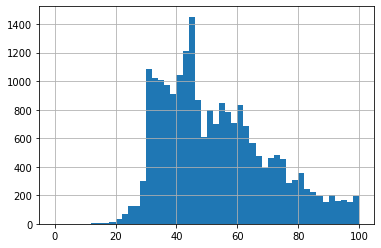

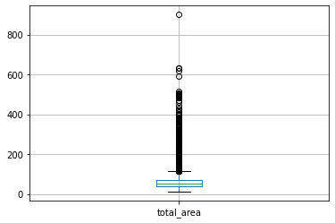

```python
data['total_area'].hist(bins= 50, range = (0,100))
plt.show()
data.boxplot(column='total_area')
plt.show()
```

Общая площадь в обявлениях в основном в приделах от 12 до 100. Есть редкие исключения большее 200.

#### Жилая площадь

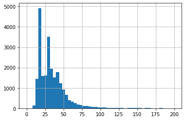

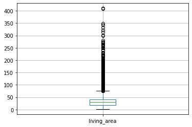

```python
data['living_area'].hist(bins= 50, range = (0,200))
plt.show()
data.boxplot(column='living_area')
plt.show()
```

Жилая площадь в обявлениях в основном в приделах от 10 до 60.

#### Площадь кухни

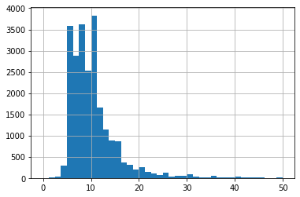

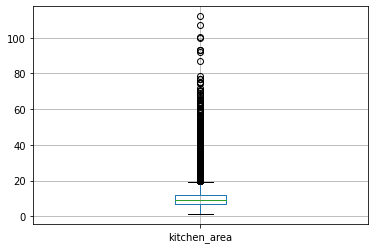

```python
data['kitchen_area'].hist(bins= 40, range = (0,50))
plt.show()
data.boxplot(column='kitchen_area')
plt.show()
```

Площадь кухни в обявлениях в основном в приделах от 5 до 15. Приветически нету больших площадей.

#### Цена объекта

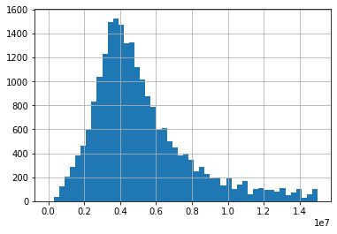

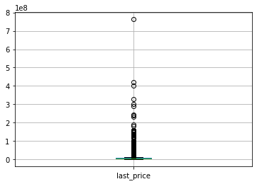

```python
data['last_price'].hist(bins= 50, range = (0,15000000))
plt.show()
data.boxplot(column='last_price')
plt.show()
```

```python
# Разбитие на категории, для наглядности
def category_price_def(row):
    price = row['last_price']
    if price < 1000000:
        return 'до 1 млн'
    elif 1000000 <= price < 2000000:
        return 'от 1 до 2 млн'
    elif 2000000 <= price < 3000000:
        return 'от 2 до 3 млн'
    elif 3000000 <= price < 4000000:
        return 'от 3 до 4 млн'
    elif 4000000 <= price < 5000000:
        return 'от 4 до 5 млн'
    elif 5000000 <= price < 6000000:
        return 'от 5 до 6 млн'
    elif 6000000 <= price < 7000000:
        return 'от 6 до 7 млн'
    else:
        return 'свыше 7 млн'

data['category_price'] = data.apply(category_price_def, axis = 1)
data.groupby('category_price', as_index=False)[['last_price']].count().sort_values('category_price', ascending=True)
```

|  | category_price | last_price |
| --- | --- | --- |
| 0 | до 1 млн | 225 |
| 1 | от 1 до 2 млн | 1138 |
| 2 | от 2 до 3 млн | 2588 |
| 3 | от 3 до 4 млн | 4824 |
| 4 | от 4 до 5 млн | 4364 |
| 5 | от 5 до 6 млн | 2969 |
| 6 | от 6 до 7 млн | 1915 |
| 7 | свыше 7 млн | 5495 |

Больше всего квартир стоит свыше 7 млн. В среднем квартира стоит 6,5 млн.

#### Количество комнат

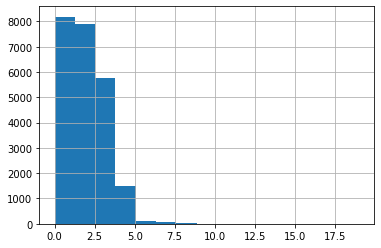

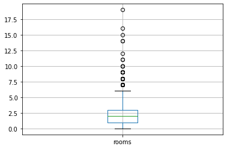

```python
data['rooms'].hist(bins= 15)
plt.show()
data.boxplot(column='rooms')
plt.show()
```

Самые популярные квартиры однокомнатные, двухкомнатные и студии.

#### Высота потолков

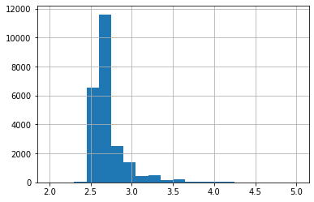

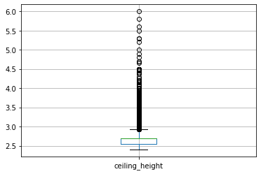

```python
data['ceiling_height'].hist(bins= 20, range = (2,5))
plt.show()
data.boxplot(column='ceiling_height')
plt.show()
```

В среднем высота потолков стоит 2,7.

#### Этаж квартиры

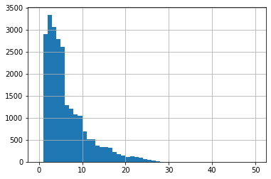

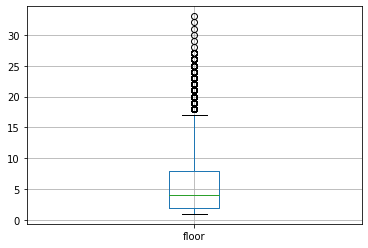

```python
data['floor'].hist(bins= 50, range = (0,50))
plt.show()
data.boxplot(column='floor')
plt.show()
```

#### Тип этажа квартиры («первый», «последний», «другой»)

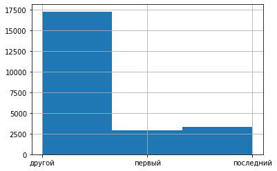

```python
data['floor_type'].hist(bins= 3)
plt.show()
#data.boxplot(column='floor_type')
#plt.show()
```

Первых и последних этажей очень мало.

#### Общее количество этажей в доме

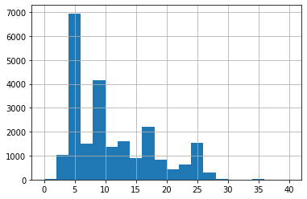

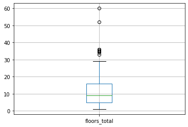

```python
data['floors_total'].hist(bins= 20, range = (0,40))
plt.show()
data.boxplot(column='floors_total')
plt.show()
```

Основная масса домов имеют 5 этажей, так же есть большое количество домов по 9 этажей.

#### Расстояние до центра города в метрах

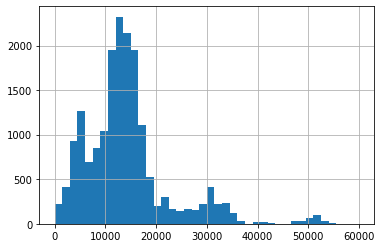

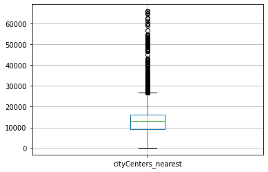

```python
data['cityCenters_nearest'].hist(bins= 40, range = (0,60000))
plt.show()
data.boxplot(column='cityCenters_nearest')
plt.show()
```

Расстояние до центра города от 5000 до 17000, большинство объявлений из Санкт-Петербурга.

#### Расстояние до ближайшего аэропорта

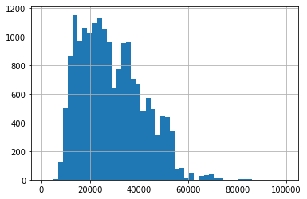

```python
data['airports_nearest'].hist(bins=50, range=(1000,100000))
plt.show()
data.boxplot(column='airports_nearest')
plt.show()
```

[output not shown]

Расстояние до ближайшего аэропорта от 10000 до 40000.

#### Расстояние до ближайшего парка

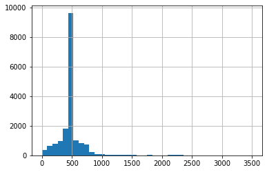

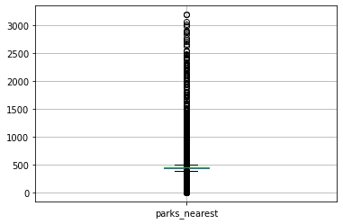

```python
data['parks_nearest'].hist(bins= 40, range = (0,3500))
plt.show()
data.boxplot(column='parks_nearest')
plt.show()
```

Расстояние до ближайшего парка от 100 до 600.

#### День и месяц публикации объявления

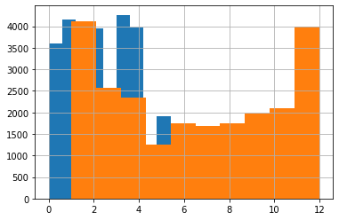

```python
data['weekday'].hist()
data['month'].hist()
plt.show()
```

### Изучение, как быстро продавались квартиры

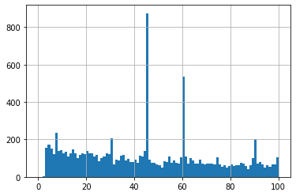

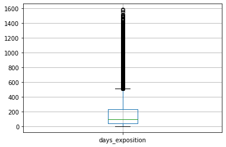

```
count    20351.000000
mean       180.857648
std        219.881747
min          1.000000
25%         45.000000
50%         95.000000
75%        231.000000
max       1580.000000
Name: days_exposition, dtype: float64
```

```python
# дата фрейм без NaN и 0 в столбце days_exposition
good_data = data.query('days_exposition > 0')
data['days_exposition'].hist(bins= 100, range = (0,100))
plt.show()
good_data.boxplot(column='days_exposition')
plt.show()
good_data['days_exposition'].describe()
```

### Факторы, больше всего влияющие на общую (полную) стоимость объекта

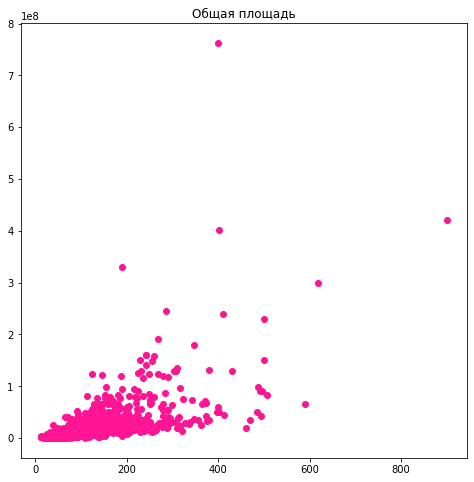

```python
# График scatter по столбцу total_area
x = good_data['total_area']    #  x - координаты точек
y = good_data['last_price']    #  y - координаты точек

fig, ax = plt.subplots()

ax.scatter(x, y,
           c = 'deeppink')    #  цвет точек

ax.set_facecolor('white')     #  цвет области Axes
ax.set_title('Общая площадь')     #  заголовок для Axes

fig.set_figwidth(8)     #  ширина и
fig.set_figheight(8)    #  высота "Figure"

plt.show()
```

Чем больше площадь, тем больше цена. С увиличением площади эта зависимость не так значительна.

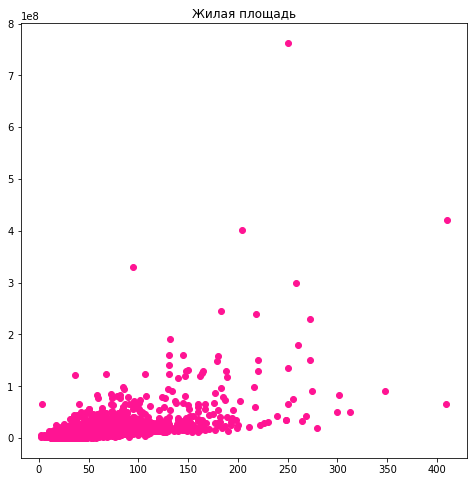

```python
# График scatter по столбцу living_area
x = good_data['living_area']    #  x - координаты точек
y = good_data['last_price']    #  y - координаты точек

fig, ax = plt.subplots()

ax.scatter(x, y,
           c = 'deeppink')    #  цвет точек

ax.set_facecolor('white')     #  цвет области Axes
ax.set_title('Жилая площадь')     #  заголовок для Axes

fig.set_figwidth(8)     #  ширина и
fig.set_figheight(8)    #  высота "Figure"

plt.show()
```

Чем больше площадь, тем больше цена.

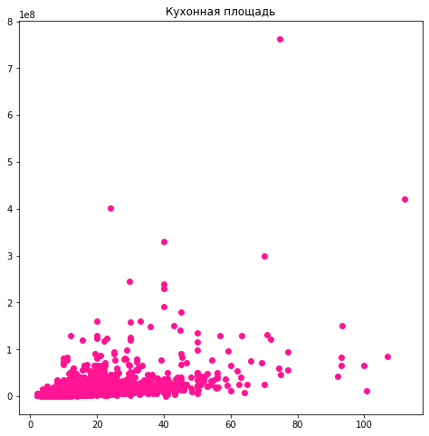

```python
# График scatter по столбцу kitchen_area
x = good_data['kitchen_area']    #  x - координаты точек
y = good_data['last_price']    #  y - координаты точек

fig, ax = plt.subplots()

ax.scatter(x, y,
           c = 'deeppink')    #  цвет точек

ax.set_facecolor('white')     #  цвет области Axes
ax.set_title('Кухонная площадь')     #  заголовок для Axes

fig.set_figwidth(8)     #  ширина и
fig.set_figheight(8)    #  высота "Figure"

plt.show()
```

Чем больше площадь, тем больше цена.

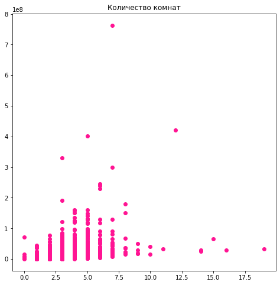

```python
# График scatter по столбцу rooms
x = good_data['rooms']    #  x - координаты точек
y = good_data['last_price']    #  y - координаты точек

fig, ax = plt.subplots()

ax.scatter(x, y,
           c = 'deeppink')    #  цвет точек

ax.set_facecolor('white')     #  цвет области Axes
ax.set_title('Количество комнат')     #  заголовок для Axes

fig.set_figwidth(8)     #  ширина и
fig.set_figheight(8)    #  высота "Figure"

plt.show()
```

Чем больше количество комнат, тем больше цена. В квартирах с большим количеством комнат эта зависимость не так значительна.

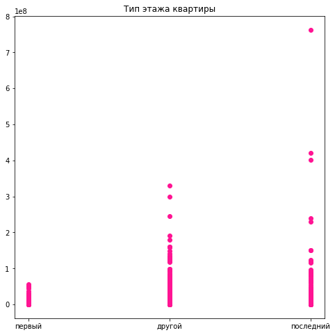

```python
# График scatter по стобцу floor_type
x = good_data['floor_type']    #  x - координаты точек
y = good_data['last_price']    #  y - координаты точек

fig, ax = plt.subplots()

ax.scatter(x, y,
           c = 'deeppink')    #  цвет точек

ax.set_facecolor('white')     #  цвет области Axes
ax.set_title('Тип этажа квартиры')     #  заголовок для Axes

fig.set_figwidth(8)     #  ширина и
fig.set_figheight(8)    #  высота "Figure"

plt.show()
```

Первый этаж стоит всех меньше. Средние этажи стоят дороже.

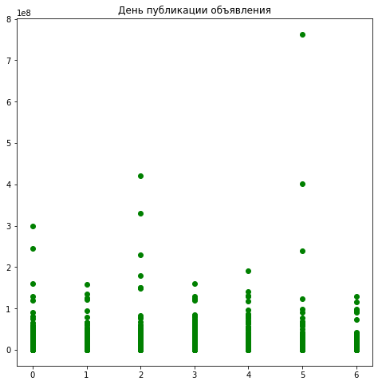

```python
# График scatter
x = good_data['weekday']    #  x - координаты точек
y = good_data['last_price']    #  y - координаты точек

fig, ax = plt.subplots()

ax.scatter(x, y,
           c = 'Green')    #  цвет точек

ax.set_facecolor('white')     #  цвет области Axes
ax.set_title('День публикации объявления')     #  заголовок для Axes

fig.set_figwidth(8)     #  ширина и
fig.set_figheight(8)    #  высота "Figure"

plt.show()
```

День недели публикации объявления не сильно влияет на цену.

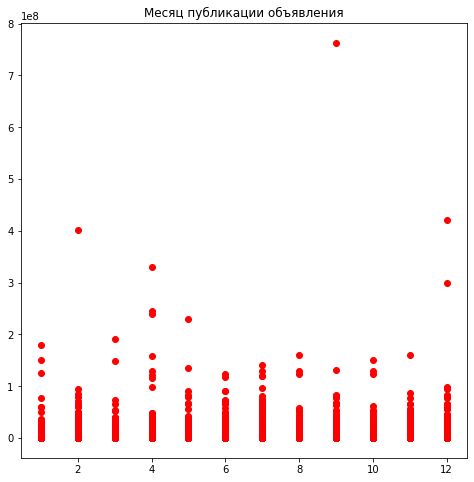

```python
# График scatter
x = good_data['month']    #  x - координаты точек
y = good_data['last_price']    #  y - координаты точек

fig, ax = plt.subplots()

ax.scatter(x, y,
           c = 'Red')    #  цвет точек

ax.set_facecolor('white')     #  цвет области Axes
ax.set_title('Месяц публикации объявления')     #  заголовок для Axes

fig.set_figwidth(8)     #  ширина и
fig.set_figheight(8)    #  высота "Figure"

plt.show()
```

Месяц публикации объявления не сильно влияет на цену.

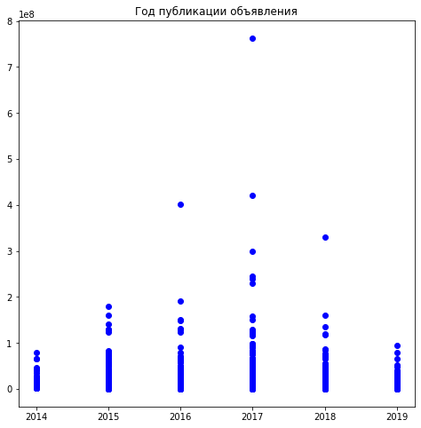

```python
# График scatter
x = good_data['year']    #  x - координаты точек
y = good_data['last_price']    #  y - координаты точек

fig, ax = plt.subplots()

ax.scatter(x, y,
           c = 'Blue')    #  цвет точек

ax.set_facecolor('white')     #  цвет области Axes
ax.set_title('Год публикации объявления')     #  заголовок для Axes

fig.set_figwidth(8)     #  ширина и
fig.set_figheight(8)    #  высота "Figure"

plt.show()
```

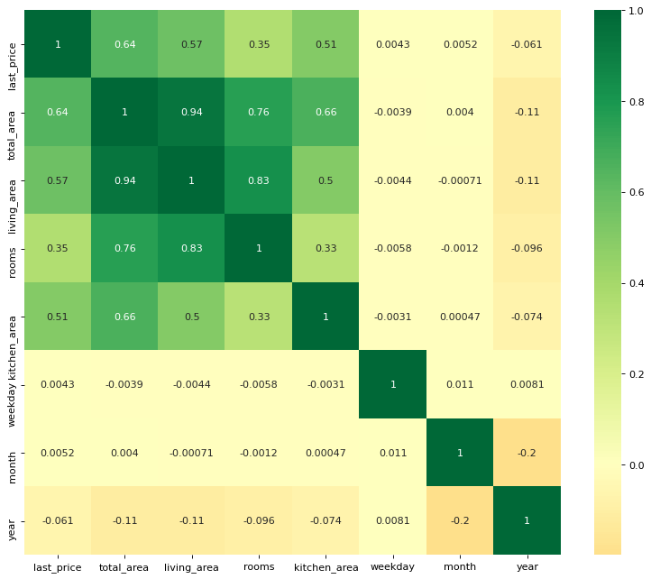

```python
# Новый дата фрейм с нужными по условию столбцами
corr_good_data = good_data[['last_price' ,'total_area', 'living_area', 'rooms','kitchen_area', 'floor_type', 'weekday', 'month', 'year']]
plt.figure(figsize=(12,10), dpi= 80)
sns.heatmap(corr_good_data.corr(), xticklabels=corr_good_data.corr().columns, yticklabels=corr_good_data.corr().columns, cmap='RdYlGn', center=0, annot=True)
plt.show()
```

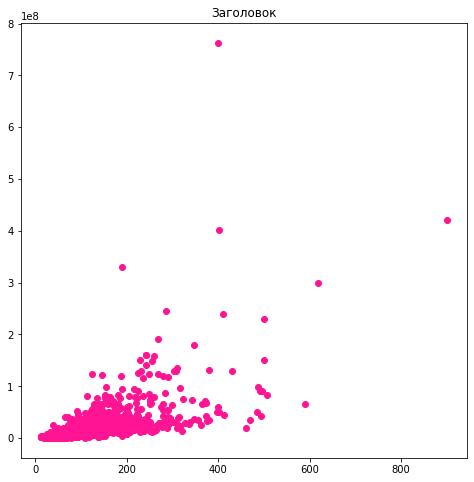

```python
import numpy as np
import matplotlib.pyplot as plt

x = good_data['total_area']    #  x - координаты точек
y = good_data['last_price']    #  y - координаты точек

fig, ax = plt.subplots()

ax.scatter(x, y,
           c = 'deeppink')    #  цвет точек

ax.set_facecolor('white')     #  цвет области Axes
ax.set_title('Заголовок')     #  заголовок для Axes

fig.set_figwidth(8)     #  ширина и
fig.set_figheight(8)    #  высота "Figure"

plt.show()
```

### Подсчет средней цены одного квадратного метра в 10 населённых пунктах с наибольшим числом объявлений. Населённые пункты с самой высокой и низкой стоимостью квадратного метра.

```python
# Сводная таблица
locality_name_head10 = round(good_data.pivot_table(index = 'locality_name', values = 'price_one_sqm', aggfunc=['count', 'mean']), 2)
locality_name_head10.columns = ['count', 'mean']
locality_name_head10 = locality_name_head10.sort_values(by='count', ascending = False).head(10)
print(locality_name_head10)

#самая высокая стоимость
locality_name_head10[locality_name_head10['mean'].max() == locality_name_head10['mean']]
#самая низкая стоимость
locality_name_head10[locality_name_head10['mean'].min() == locality_name_head10['mean']]
```

```
                   count       mean
locality_name
Санкт-Петербург    13556  112387.44
поселок Мурино       547   85691.01
поселок Шушары       407   77872.60
Всеволожск           339   68570.62
Колпино              308   74865.36
Пушкин               307  102074.63
поселок Парголово    302   89505.04
деревня Кудрово      298   92455.03
Гатчина              268   67928.33
Выборг               206   57184.10
```

| locality_name | count | mean |
| --- | --- | --- |
| Выборг | 206 | 57184.1 |

Cамая высокая стоимость жилья и самое большое количество объявлений в Санкт-Петербурге. Самая низкая стоимость в Выборге.

### Средняя цена каждого километра от центра в Санкт-Петербурге. Как стоимость объектов зависит от расстояния до центра города.

```python
# дата фрейм без NaN в столбце cityCenters_nearest_km
best_data = good_data.query('cityCenters_nearest_km >= 0')
best_data['cityCenters_nearest_km'] = best_data['cityCenters_nearest_km'].astype('int')
# Сводная таблица
spb_cityCenters_nearest = round(best_data.query('locality_name == "Санкт-Петербург"').pivot_table(index = 'cityCenters_nearest_km', values = 'price_one_sqm', aggfunc=['count', 'mean']), 2)
spb_cityCenters_nearest.columns = ['count', 'mean']
spb_cityCenters_nearest.sort_values(by='mean', ascending = False)
```

| cityCenters_nearest_km | count | mean |
| --- | --- | --- |
| 0 | 19 | 226876.50 |
| 1 | 164 | 159665.42 |
| 2 | 255 | 156201.31 |
| 7 | 347 | 151276.37 |
| 6 | 521 | 147837.95 |
| 5 | 775 | 138812.08 |
| 4 | 575 | 132408.06 |
| 27 | 2 | 132115.71 |
| 8 | 513 | 122854.02 |
| 3 | 274 | 116908.01 |
| 10 | 632 | 111026.30 |
| 9 | 515 | 110726.49 |
| 12 | 1425 | 107136.34 |
| 13 | 1299 | 106429.28 |
| 11 | 1028 | 106184.33 |
| 14 | 1117 | 103015.46 |
| 15 | 1363 | 102173.23 |
| 20 | 39 | 100914.51 |
| 16 | 1112 | 98875.01 |
| 19 | 142 | 98709.50 |
| 17 | 775 | 95918.65 |
| 18 | 228 | 95169.58 |
| 25 | 26 | 91531.37 |
| 21 | 94 | 91336.87 |
| 22 | 172 | 90260.34 |
| 23 | 64 | 89830.24 |
| 26 | 42 | 87832.11 |
| 24 | 26 | 85736.90 |
| 28 | 7 | 81161.91 |
| 29 | 5 | 76238.68 |

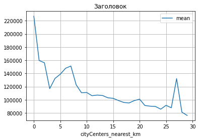

```python
# Линейная диаграмма
spb_cityCenters_nearest.plot(y = 'mean', grid = True, title = 'Заголовок')
plt.show()
```

Чем ближе квартиры к центру, тем дороже, как почти во всех городах. На растоянии 27 киллометров от центра, цена тоже дорогая, но в расчет не берем, там всего 2 объявления, возможно это элитный район.

## Общий вывод

Рассмотрели данные архива Яндекс.Недвижимость - объявления о продаже квартир в Санкт-Петербурге и соседних населённых пунктов за несколько лет.

Обработали полученный архив данных: обработали пропущенные значения там, где это необходимо, заменили типы данных на необходимые для удобной работы. Устранили редкие и выбивающиеся значения, поправили названия населённых пунктов.

Посчитали и добавили в таблицу цену квадратного метра жилья, вывели из даты дни недели, месяцы и года размещения объявлений, добавили категории по этажам квартир, перевели расстояние от центра города в километры.

Изучили факторы влияющие на стоимость квартиры: как быстро продавались квартиры, Факторы, больше всего влияющие на общую (полную) стоимость объекта, Подсчет средней цены одного квадратного метра в 10 населённых пунктах с наибольшим числом объявлений. Населённые пункты с самой высокой и низкой стоимостью квадратного метра, Средняя цена каждого километра от центра в Санкт-Петербурге. Как стоимость объектов зависит от расстояния до центра города.

Получаем следующие выводы:

Важно учитывать, что, рассматривая среднюю стоимость квартир за определенные года, мы не рассматривали года по отдельности, а лишь смотрели средние показатели. Возможно, что цены на аналогичные квартиры в разных годах могли сильно отличаться.

Пропущено достаточно много значений, необходимо многие поля сделать обязательными для заполнения. Так же были аномальные значения, добавить проверку или ограничения на ввод данных, например для высоты потолка.